# R tutorial; Solstrand seminar 2019

Julia Romanowska

2020-02-03

- load the necessary libraries:

```r
library( tidyverse )
```

# 1 READ DATA

Read the data from the file (downloaded from SSB, public data):

```r
orig.table <- read_csv2( file = "PasientSomatSykeh.csv", skip = 2 )
```

```
## Using ',' as decimal and '.' as grouping mark. Use read_delim() for more control.
```

```r
orig.table
```

```
## # A tibble: 14 x 31
##    region kjonn alder `Pasienter paa … `Pasienter paa … `Pasienter paa …
##    <chr>  <chr> <chr>            <dbl>            <dbl>            <dbl>
##  1 12 Ho… Menn  0-9 …            11734            11479            11490
##  2 12 Ho… Menn  10-1…             6250             6351             6514
##  3 12 Ho… Menn  20-3…            13648            14465            14873
##  4 12 Ho… Menn  40-5…            17068            17657            18314
##  5 12 Ho… Menn  60-6…            10547            11011            11119
##  6 12 Ho… Menn  70-7…             7323             7655             8135
##  7 12 Ho… Menn  80 a…             5260             5356             5528
##  8 12 Ho… Kvin… 0-9 …            10169             9735             9796
##  9 12 Ho… Kvin… 10-1…             6199             6398             6704
## 10 12 Ho… Kvin… 20-3…            23934            24354            25492
## 11 12 Ho… Kvin… 40-5…            19578            20151            20721
## 12 12 Ho… Kvin… 60-6…            10192            10579            10791
## 13 12 Ho… Kvin… 70-7…             7883             8200             8368
## 14 12 Ho… Kvin… 80 a…             8279             8381             8465
## # … with 25 more variables: `Pasienter paa somatiske sykehus totalt
## #   2015` <dbl>, `Pasienter paa somatiske sykehus totalt 2016` <dbl>,
## #   `Pasienter paa somatiske sykehus totalt 2017` <dbl>, `Pasienter paa
## #   somatiske sykehus totalt 2018` <dbl>, `Pasienter med dognopphold
## #   2012` <dbl>, `Pasienter med dognopphold 2013` <dbl>, `Pasienter med
## #   dognopphold 2014` <dbl>, `Pasienter med dognopphold 2015` <dbl>, `Pasienter
## #   med dognopphold 2016` <dbl>, `Pasienter med dognopphold 2017` <dbl>,
## #   `Pasienter med dognopphold 2018` <dbl>, `Pasienter med dagbehandling
## #   2012` <dbl>, `Pasienter med dagbehandling 2013` <dbl>, `Pasienter med
## #   dagbehandling 2014` <dbl>, `Pasienter med dagbehandling 2015` <dbl>,
## #   `Pasienter med dagbehandling 2016` <dbl>, `Pasienter med dagbehandling
## #   2017` <dbl>, `Pasienter med dagbehandling 2018` <dbl>, `Pasienter paa
## #   poliklinikk 2012` <dbl>, `Pasienter paa poliklinikk 2013` <dbl>, `Pasienter
## #   paa poliklinikk 2014` <dbl>, `Pasienter paa poliklinikk 2015` <dbl>,
## #   `Pasienter paa poliklinikk 2016` <dbl>, `Pasienter paa poliklinikk
## #   2017` <dbl>, `Pasienter paa poliklinikk 2018` <dbl>
```

# 2 REORDER TABLE

Create a “year” variable

```r
tab.reordered <- orig.table %>%
    gather( key = "gruppe", value = "antall.pasienter", ends_with( "2012" ) )
tab.reordered
```

```
## # A tibble: 56 x 29
##    region kjonn alder `Pasienter paa … `Pasienter paa … `Pasienter paa …
##    <chr>  <chr> <chr>            <dbl>            <dbl>            <dbl>
##  1 12 Ho… Menn  0-9 …            11479            11490            12957
##  2 12 Ho… Menn  10-1…             6351             6514             8905
##  3 12 Ho… Menn  20-3…            14465            14873            19450
##  4 12 Ho… Menn  40-5…            17657            18314            21025
##  5 12 Ho… Menn  60-6…            11011            11119            11946
##  6 12 Ho… Menn  70-7…             7655             8135             8906
##  7 12 Ho… Menn  80 a…             5356             5528             5809
##  8 12 Ho… Kvin… 0-9 …             9735             9796            10966
##  9 12 Ho… Kvin… 10-1…             6398             6704             8902
## 10 12 Ho… Kvin… 20-3…            24354            25492            29373
## # … with 46 more rows, and 23 more variables: `Pasienter paa somatiske sykehus
## #   totalt 2016` <dbl>, `Pasienter paa somatiske sykehus totalt 2017` <dbl>,
## #   `Pasienter paa somatiske sykehus totalt 2018` <dbl>, `Pasienter med
## #   dognopphold 2013` <dbl>, `Pasienter med dognopphold 2014` <dbl>, `Pasienter
## #   med dognopphold 2015` <dbl>, `Pasienter med dognopphold 2016` <dbl>,
## #   `Pasienter med dognopphold 2017` <dbl>, `Pasienter med dognopphold
## #   2018` <dbl>, `Pasienter med dagbehandling 2013` <dbl>, `Pasienter med
## #   dagbehandling 2014` <dbl>, `Pasienter med dagbehandling 2015` <dbl>,
## #   `Pasienter med dagbehandling 2016` <dbl>, `Pasienter med dagbehandling
## #   2017` <dbl>, `Pasienter med dagbehandling 2018` <dbl>, `Pasienter paa
## #   poliklinikk 2013` <dbl>, `Pasienter paa poliklinikk 2014` <dbl>, `Pasienter
## #   paa poliklinikk 2015` <dbl>, `Pasienter paa poliklinikk 2016` <dbl>,
## #   `Pasienter paa poliklinikk 2017` <dbl>, `Pasienter paa poliklinikk
## #   2018` <dbl>, gruppe <chr>, antall.pasienter <dbl>
```

```r
tab.reordered %>% select( region, kjonn, alder, gruppe, antall.pasienter )
```

```
## # A tibble: 56 x 5
##    region     kjonn   alder        gruppe                       antall.pasienter
##    <chr>      <chr>   <chr>        <chr>                                   <dbl>
##  1 12 Hordal… Menn    0-9 aar      Pasienter paa somatiske syk…            11734
##  2 12 Hordal… Menn    10-19 aar    Pasienter paa somatiske syk…             6250
##  3 12 Hordal… Menn    20-39 aar    Pasienter paa somatiske syk…            13648
##  4 12 Hordal… Menn    40-59 aar    Pasienter paa somatiske syk…            17068
##  5 12 Hordal… Menn    60-69 aar    Pasienter paa somatiske syk…            10547
##  6 12 Hordal… Menn    70-79 aar    Pasienter paa somatiske syk…             7323
##  7 12 Hordal… Menn    80 aar elle… Pasienter paa somatiske syk…             5260
##  8 12 Hordal… Kvinner 0-9 aar      Pasienter paa somatiske syk…            10169
##  9 12 Hordal… Kvinner 10-19 aar    Pasienter paa somatiske syk…             6199
## 10 12 Hordal… Kvinner 20-39 aar    Pasienter paa somatiske syk…            23934
## # … with 46 more rows
```

ok, that’s working - do the same with the other columns

```r
tab.new <- orig.table %>%
    gather( key = "gruppe", value = "antall.pasienter", starts_with( "Pasienter" ) )
tab.new
```

```
## # A tibble: 392 x 5
##    region     kjonn   alder        gruppe                       antall.pasienter
##    <chr>      <chr>   <chr>        <chr>                                   <dbl>
##  1 12 Hordal… Menn    0-9 aar      Pasienter paa somatiske syk…            11734
##  2 12 Hordal… Menn    10-19 aar    Pasienter paa somatiske syk…             6250
##  3 12 Hordal… Menn    20-39 aar    Pasienter paa somatiske syk…            13648
##  4 12 Hordal… Menn    40-59 aar    Pasienter paa somatiske syk…            17068
##  5 12 Hordal… Menn    60-69 aar    Pasienter paa somatiske syk…            10547
##  6 12 Hordal… Menn    70-79 aar    Pasienter paa somatiske syk…             7323
##  7 12 Hordal… Menn    80 aar elle… Pasienter paa somatiske syk…             5260
##  8 12 Hordal… Kvinner 0-9 aar      Pasienter paa somatiske syk…            10169
##  9 12 Hordal… Kvinner 10-19 aar    Pasienter paa somatiske syk…             6199
## 10 12 Hordal… Kvinner 20-39 aar    Pasienter paa somatiske syk…            23934
## # … with 382 more rows
```

## 2.1 EXERCISE 1

Use ‘select’ to remove the ‘region’ variable

```r
tab.new <- tab.new %>% select( -region )
```

Now, we need to extract year

```r
tab.new2 <- tab.new %>%
    mutate( aar = word(gruppe, -1)) %>%
      mutate( gruppe = word(gruppe, 1, -2)) %>%
      mutate( aar = as.numeric(aar))
tab.new2
```

```
## # A tibble: 392 x 5
##    kjonn   alder           gruppe                         antall.pasienter   aar
##    <chr>   <chr>           <chr>                                     <dbl> <dbl>
##  1 Menn    0-9 aar         Pasienter paa somatiske sykeh…            11734  2012
##  2 Menn    10-19 aar       Pasienter paa somatiske sykeh…             6250  2012
##  3 Menn    20-39 aar       Pasienter paa somatiske sykeh…            13648  2012
##  4 Menn    40-59 aar       Pasienter paa somatiske sykeh…            17068  2012
##  5 Menn    60-69 aar       Pasienter paa somatiske sykeh…            10547  2012
##  6 Menn    70-79 aar       Pasienter paa somatiske sykeh…             7323  2012
##  7 Menn    80 aar eller e… Pasienter paa somatiske sykeh…             5260  2012
##  8 Kvinner 0-9 aar         Pasienter paa somatiske sykeh…            10169  2012
##  9 Kvinner 10-19 aar       Pasienter paa somatiske sykeh…             6199  2012
## 10 Kvinner 20-39 aar       Pasienter paa somatiske sykeh…            23934  2012
## # … with 382 more rows
```

```r
class( tab.new2$gruppe )
```

```
## [1] "character"
```

```r
unique( tab.new2$gruppe )
```

```
## [1] "Pasienter paa somatiske sykehus totalt"
## [2] "Pasienter med dognopphold"
## [3] "Pasienter med dagbehandling"
## [4] "Pasienter paa poliklinikk"
```

## 2.2 EXERCISE 2

Do the same (check what class and unique values) with the ‘aar’ variable

```r
class( tab.new2$aar )
```

```
## [1] "numeric"
```

```r
unique( tab.new2$aar )
```

```
## [1] 2012 2013 2014 2015 2016 2017 2018
```

Now, we’ll re-format the year

```r
tab.new2$aar <- as.numeric( tab.new2$aar )

tab.new2
```

```
## # A tibble: 392 x 5
##    kjonn   alder           gruppe                         antall.pasienter   aar
##    <chr>   <chr>           <chr>                                     <dbl> <dbl>
##  1 Menn    0-9 aar         Pasienter paa somatiske sykeh…            11734  2012
##  2 Menn    10-19 aar       Pasienter paa somatiske sykeh…             6250  2012
##  3 Menn    20-39 aar       Pasienter paa somatiske sykeh…            13648  2012
##  4 Menn    40-59 aar       Pasienter paa somatiske sykeh…            17068  2012
##  5 Menn    60-69 aar       Pasienter paa somatiske sykeh…            10547  2012
##  6 Menn    70-79 aar       Pasienter paa somatiske sykeh…             7323  2012
##  7 Menn    80 aar eller e… Pasienter paa somatiske sykeh…             5260  2012
##  8 Kvinner 0-9 aar         Pasienter paa somatiske sykeh…            10169  2012
##  9 Kvinner 10-19 aar       Pasienter paa somatiske sykeh…             6199  2012
## 10 Kvinner 20-39 aar       Pasienter paa somatiske sykeh…            23934  2012
## # … with 382 more rows
```

# 3 CALCULATE AND MANIPULATE DATA

group by year

```r
tab.groupped <- tab.new2 %>% group_by( aar )
tab.groupped
```

```
## # A tibble: 392 x 5
## # Groups:   aar [7]
##    kjonn   alder           gruppe                         antall.pasienter   aar
##    <chr>   <chr>           <chr>                                     <dbl> <dbl>
##  1 Menn    0-9 aar         Pasienter paa somatiske sykeh…            11734  2012
##  2 Menn    10-19 aar       Pasienter paa somatiske sykeh…             6250  2012
##  3 Menn    20-39 aar       Pasienter paa somatiske sykeh…            13648  2012
##  4 Menn    40-59 aar       Pasienter paa somatiske sykeh…            17068  2012
##  5 Menn    60-69 aar       Pasienter paa somatiske sykeh…            10547  2012
##  6 Menn    70-79 aar       Pasienter paa somatiske sykeh…             7323  2012
##  7 Menn    80 aar eller e… Pasienter paa somatiske sykeh…             5260  2012
##  8 Kvinner 0-9 aar         Pasienter paa somatiske sykeh…            10169  2012
##  9 Kvinner 10-19 aar       Pasienter paa somatiske sykeh…             6199  2012
## 10 Kvinner 20-39 aar       Pasienter paa somatiske sykeh…            23934  2012
## # … with 382 more rows
```

## 3.1 EXERCISE 3

Group by “gruppe” additionally to “aar”

```r
tab.groupped <- tab.new2 %>% group_by( aar, gruppe )
```

How to use this grouping? Calculate sum of patients per year and group

```r
tab.sum <- tab.groupped %>% summarise( sum = sum( antall.pasienter ) )
tab.sum
```

```
## # A tibble: 28 x 3
## # Groups:   aar [7]
##      aar gruppe                                    sum
##    <dbl> <chr>                                   <dbl>
##  1  2012 Pasienter med dagbehandling             16681
##  2  2012 Pasienter med dognopphold               59558
##  3  2012 Pasienter paa poliklinikk              136451
##  4  2012 Pasienter paa somatiske sykehus totalt 158064
##  5  2013 Pasienter med dagbehandling             17334
##  6  2013 Pasienter med dognopphold               60498
##  7  2013 Pasienter paa poliklinikk              140251
##  8  2013 Pasienter paa somatiske sykehus totalt 161772
##  9  2014 Pasienter med dagbehandling             17512
## 10  2014 Pasienter med dognopphold               60646
## # … with 18 more rows
```

# 4 PLOT

plotting total numbers for each year

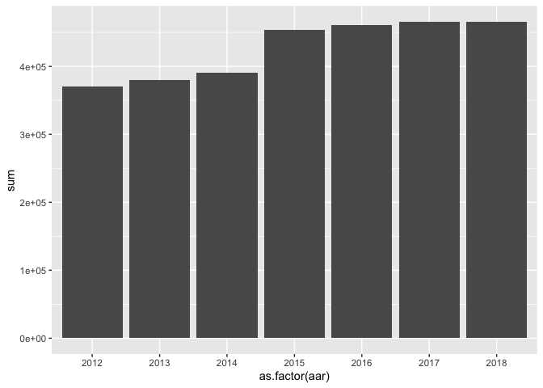

```r
ggplot( tab.sum, aes( x = as.factor( aar ), y = sum ) ) +
    geom_col()
```

plotting the same using lines

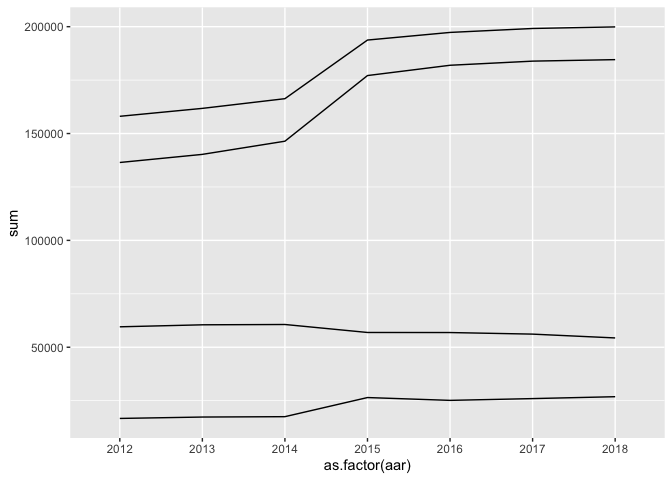

```r
ggplot( tab.sum, aes( x = as.factor( aar ), y = sum ) ) +
    geom_line( aes( group = gruppe ) )
```

add color

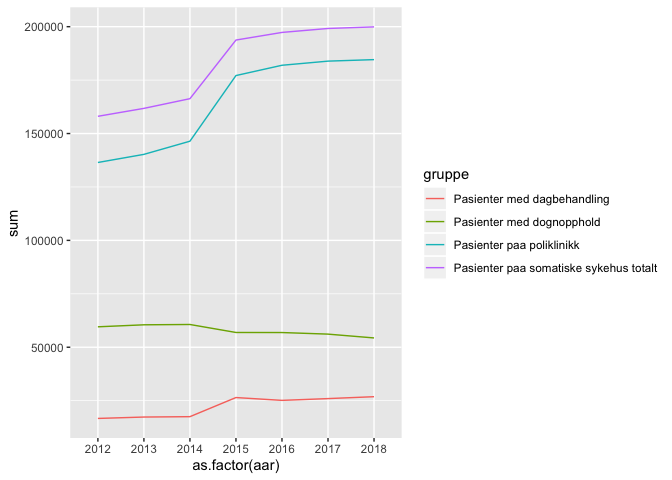

```r
ggplot( tab.sum, aes( x = as.factor( aar ), y = sum ) ) +
    geom_line( aes( group = gruppe, col = gruppe ) )
```

## 4.1 EXERCISE 4

Exercise: plotting totals, using bars, fill color by “gruppe”

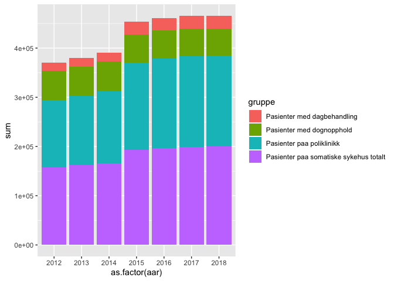

```r
ggplot( tab.sum, aes( x = as.factor( aar ), y = sum ) ) +
    geom_col( aes( fill = gruppe ) )
```

Now, plotting totals, grouped, non-stacked

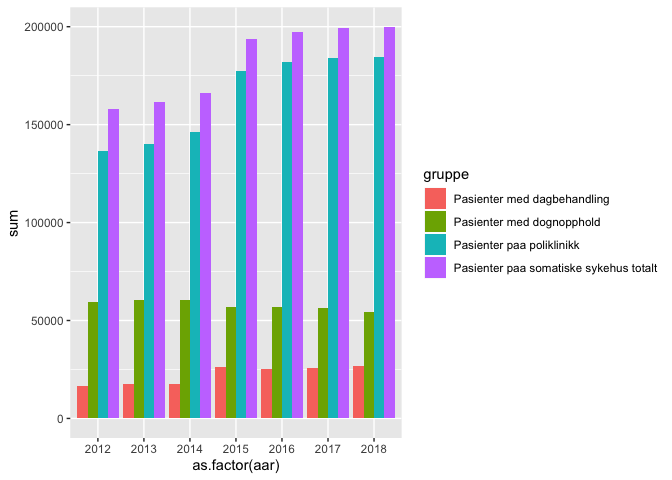

```r
ggplot( tab.sum, aes( x = as.factor( aar ), y = sum ) ) +
    geom_col( aes( fill = gruppe ), position = position_dodge() )
```

splitting this - checking difference with regard to gender

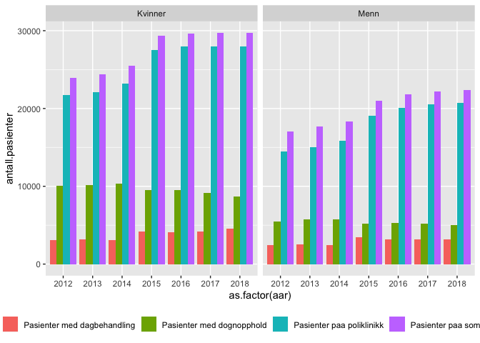

```r
ggplot( tab.groupped, aes( x = as.factor( aar ), y = antall.pasienter ) ) +
    geom_col( aes( fill = gruppe ), position = position_dodge() ) +
    facet_wrap( facets = vars( kjonn ) ) +
    theme( legend.position = "bottom" )
```

splitting again - with regard to age

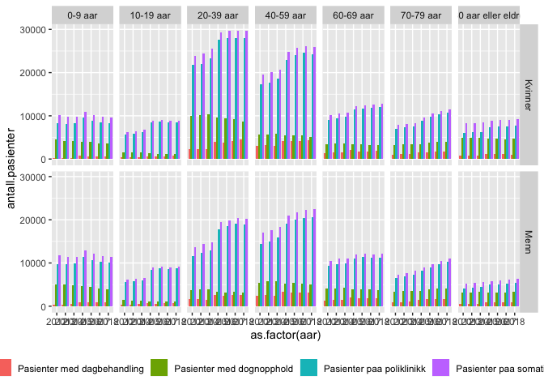

```r
final.plot <- ggplot( tab.groupped, aes( x = as.factor( aar ), y = antall.pasienter ) ) +
    geom_col( aes( fill = gruppe ), position = position_dodge() ) +
    facet_grid( rows = vars( kjonn ), cols = vars( alder ) ) +
    theme( legend.position = "bottom" )
final.plot
```

## 4.2 EXERCISE 5

Exercise: plot the same (final.plot) using lines

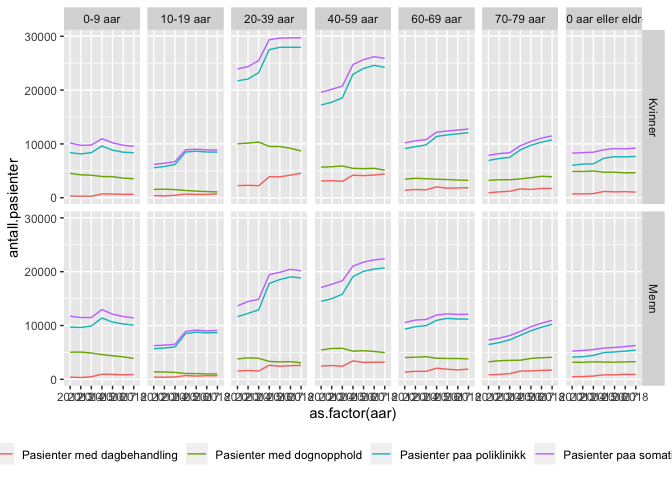

```r
final.plot.lines <- ggplot( tab.groupped, aes( x = as.factor( aar ), y = antall.pasienter ) ) +
    geom_line( aes( col = gruppe, group = gruppe ) ) +
    facet_grid( rows = vars( kjonn ), cols = vars( alder ) ) +
    theme( legend.position = "bottom" )
final.plot.lines
```

Now, adjusting the looks:

- better axis titles and title

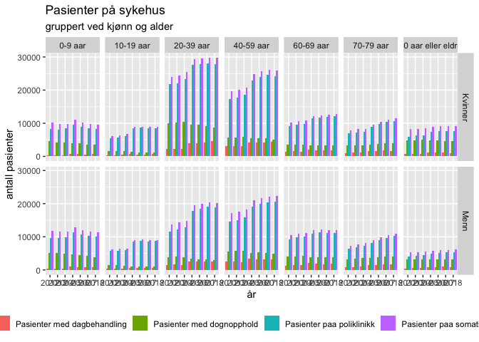

```r
final.plot <- final.plot +
    xlab( "år" ) + ylab( "antall pasienter" ) +
    labs( title = "Pasienter på sykehus", subtitle = "gruppert ved kjønn og alder" )
final.plot
```

- vertical x axis labels

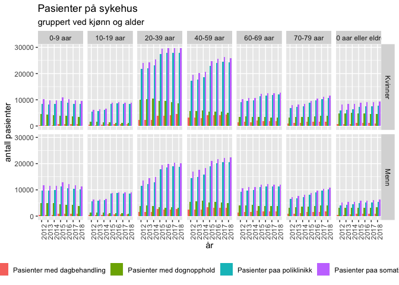

```r
final.plot <- final.plot + theme( axis.text.x = element_text( angle = 90 ) )
final.plot
```

- two rows in legend

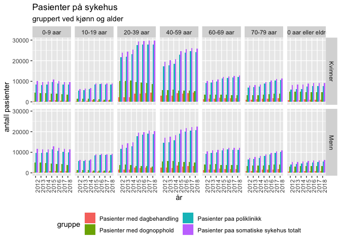

```r
final.plot <- final.plot + guides( fill = guide_legend( nrow = 2 ) )
final.plot
```

Additional things: + anything else they want to change in the layout? + save the plot to a file + show them where to search for help + click on “compile”